# Шестой этап индивидуального проекта

Операционные системы

Панина Ж. В.

Российский университет дружбы народов, Москва, Россия

31 мая 2025

# Информация

## Докладчик

- Панина Жанна Валерьевна
- НКАбд-02-24, студ. билет № 1132246710
- студент направления “Компьютерные и информационные науки”
- Российский университет дружбы народов
- 1132246710@pfur.ru
- https://github.com/zvpanina/study_2024-2025_os-intro

# Вводная часть

## Актуальность

В условиях стремительного развития цифровых технологий персональные сайты становятся важным инструментом самопрезентации, хранения портфолио и ведения блога. Многоязычность сайта существенно расширяет его аудиторию и способствует лучшей коммуникации с пользователями из разных стран. Создание персонального сайта с поддержкой русского и английского языков позволяет не только продемонстрировать навыки веб-разработки, но и адаптировать цифровое пространство под глобальные стандарты информационной доступности.

## Объект и предмет исследования

### Объект исследования:

Персональный сайт как средство цифровой самопрезентации и коммуникации.

### Предмет исследования:

Технологические и языковые аспекты реализации многоязычного веб-сайта на примере персонального сайта студента.

## Цели и задачи

Продолжить работу с сайтом, разместить двуязычный сайт на Github, а также сделать пост по прошедшей неделе и пост по выбору.

# Задачи

1. Сделать поддержку английского и русского языков.
2. Разместить элементы сайта на обоих языках.
3. Разместить контент на обоих языках.
4. Сделать пост по прошедшей неделе.
5. Добавить пост на тему по выбору (на двух языках).

## Материалы и методы исследования

### Материалы:

- Фреймворк Hugo
- Markdown-файлы контента
- Структура шаблонов (layouts, partials)
- Контент на русском и английском языках
- CSS/HTML

### Методы:

- Метод проектирования пользовательского интерфейса
- Метод ручной и автоматизированной вёрстки контента
- Метод лингвистической адаптации информации
- Метод тестирования и локализации сайта
- Сравнительный анализ отображения элементов интерфейса на разных языках

# Выполнение индивидуального проекта

1. Редактирую .yaml файлы для поддержки русского и английского языков.

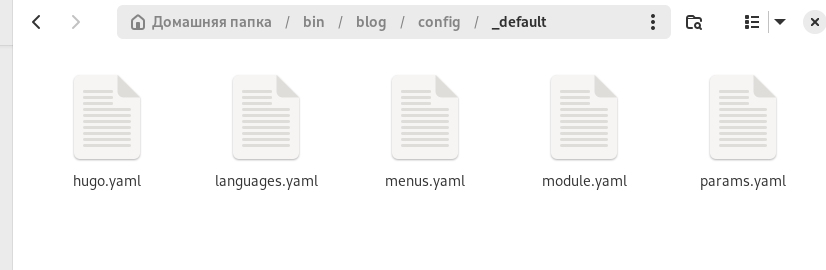

Добавление языков в .yaml файлах

В папке /blog/content создаю две папки - en и ru. Помещаю в них все ранее созданные посты и файлы в двух вариантах. Всё, что было написано на русском языке, я перевела на английский, и наоборот.

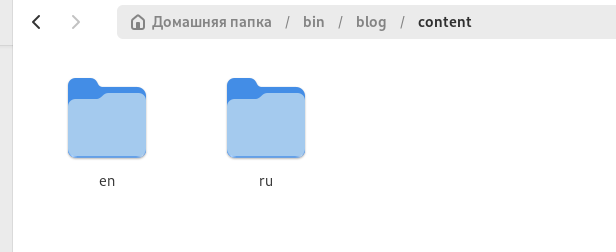

Разделение конттента на две папки

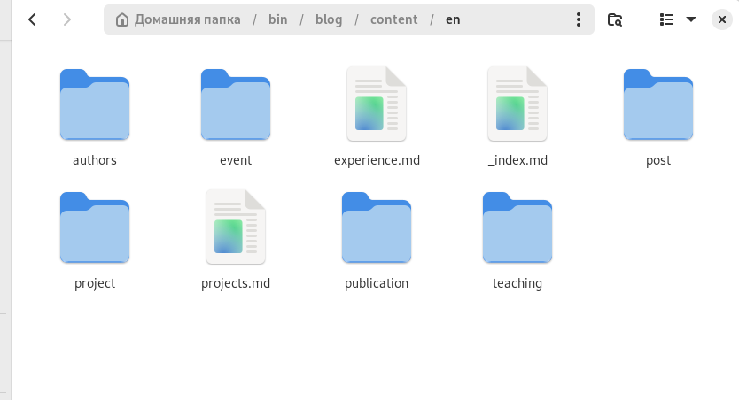

Переведённые файлы в английской папке

2. Начинаю редактировать файл для поста о прошедшей неделе.

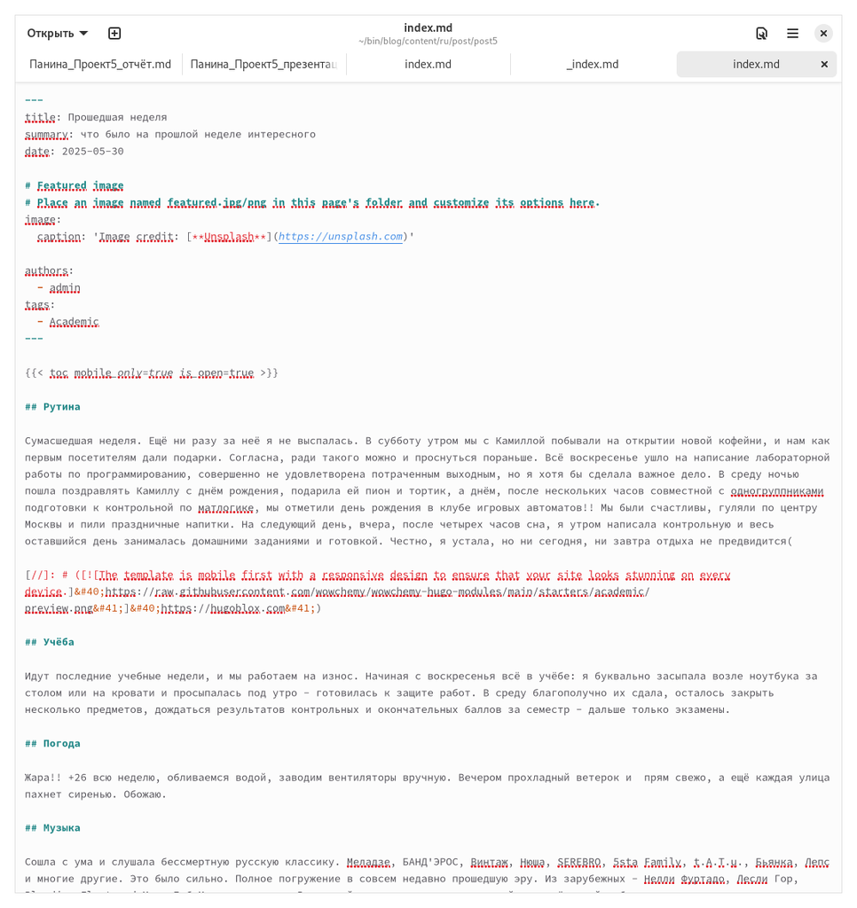

Подготовка поста “Прошедшая неделя”

Добавляю фотографию к посту в нужный каталог.

[figure not shown]

Добавление фотографии, сделанной на прошедшей неделе

3. Начинаю редактировать файл для поста по выбору.

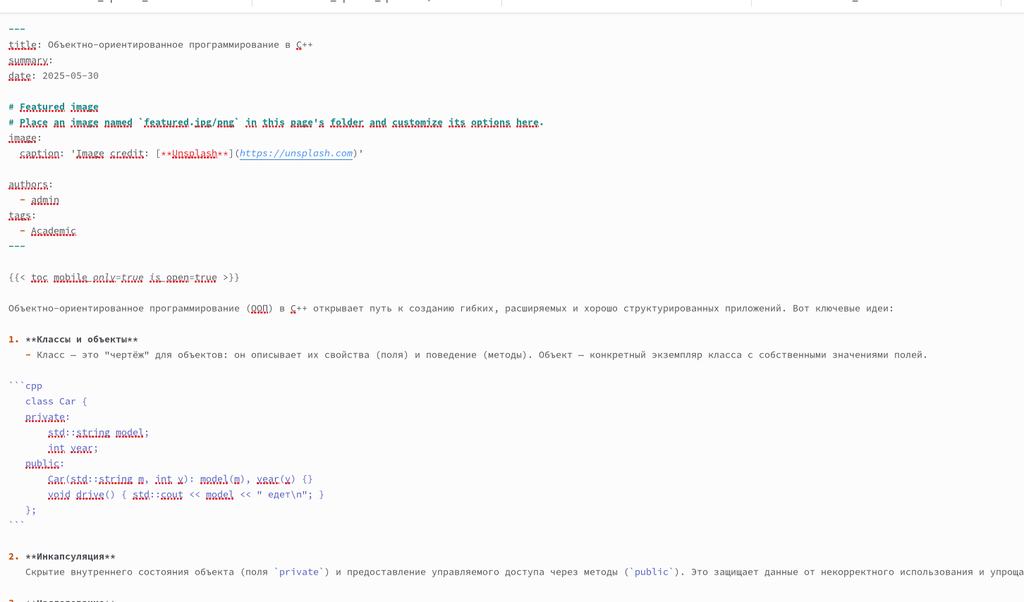

Подготовка поста “Объектно-ориентированное программирование в C++”

Добавляю фотографию к посту в нужный каталог.

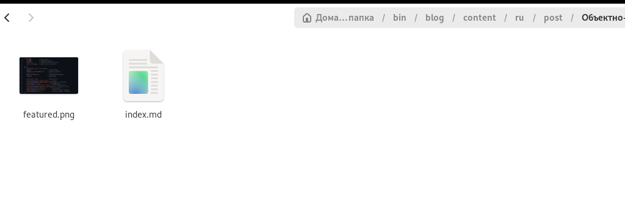

Добавление фотографии к посту

То же самое делаю в английском варианте.

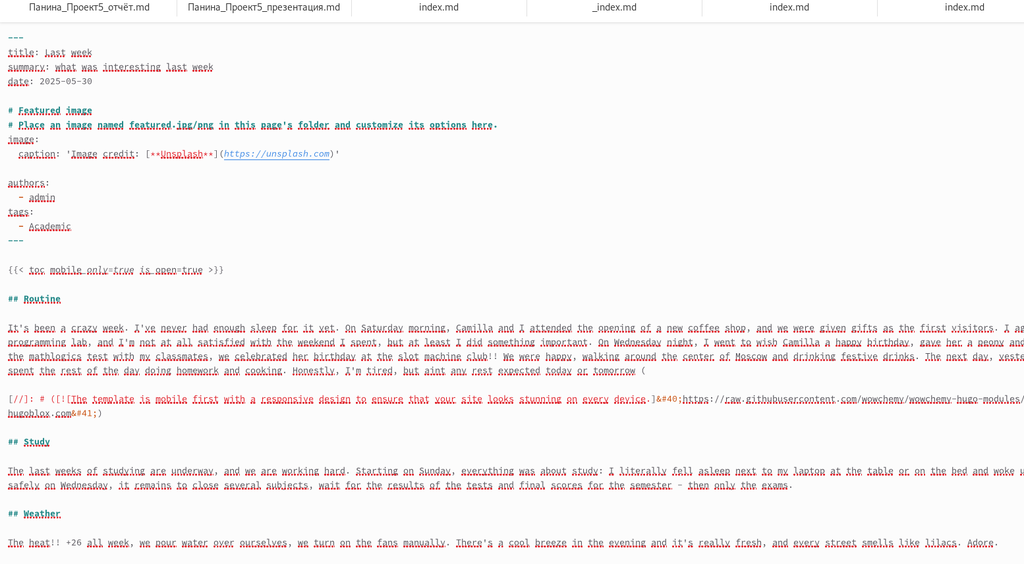

Пост о прошедшей неделе на английском языке

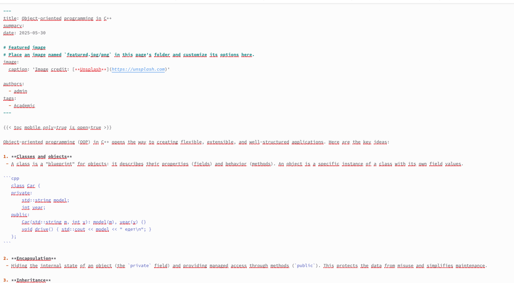

Пост про объектно-ориентированное программирование на английском языке

4. Запускаю сайт командой server, чтобы проверить изменения.

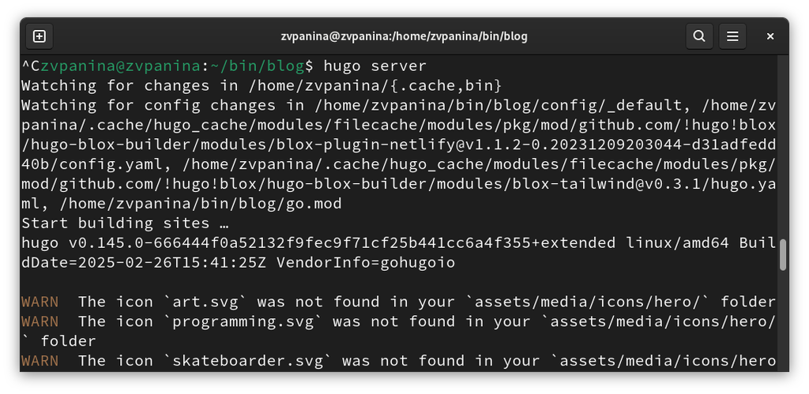

Запуск сайта

Проверяю изменения на сайте. В правом верхнем углу появилась кнопка с выбором языка. Так выглядит страница в английском варианте.

[figure not shown]

Страница на английском

Также выложены оба поста.

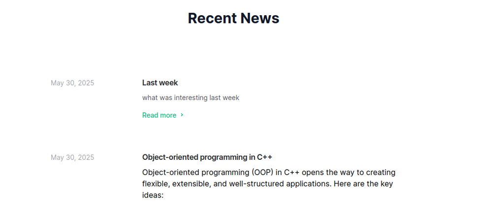

Выложенные посты

5. Отправляю изменения на глобальный репозиторий.

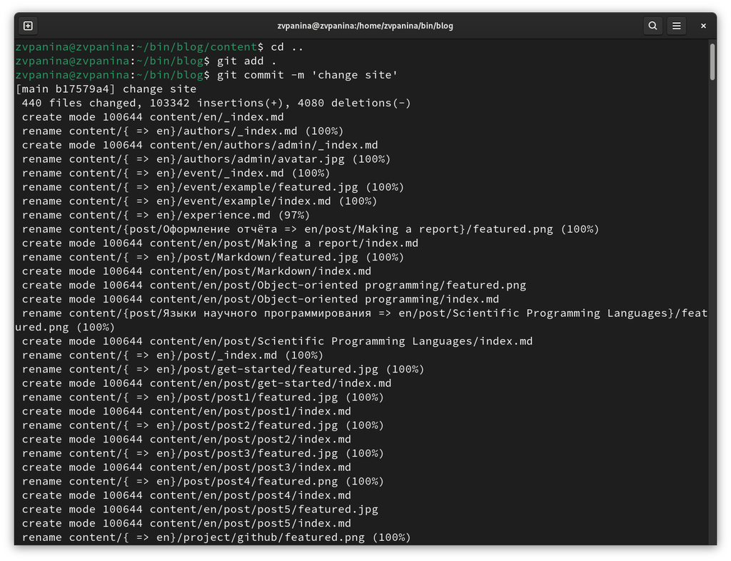